## Exercise 3 Logistic regression

```r
alc<-read.table(file = "alc.txt", sep="\t", header=TRUE)

dim(alc)
```

```
## [1] 382  35
```

```r
str(alc)
```

```
## 'data.frame':    382 obs. of  35 variables:
##  $ school    : chr  "GP" "GP" "GP" "GP" ...
##  $ sex       : chr  "F" "F" "F" "F" ...
##  $ age       : int  18 17 15 15 16 16 16 17 15 15 ...
##  $ address   : chr  "U" "U" "U" "U" ...
##  $ famsize   : chr  "GT3" "GT3" "LE3" "GT3" ...
##  $ Pstatus   : chr  "A" "T" "T" "T" ...
##  $ Medu      : int  4 1 1 4 3 4 2 4 3 3 ...
##  $ Fedu      : int  4 1 1 2 3 3 2 4 2 4 ...
##  $ Mjob      : chr  "at_home" "at_home" "at_home" "health" ...
##  $ Fjob      : chr  "teacher" "other" "other" "services" ...
##  $ reason    : chr  "course" "course" "other" "home" ...
##  $ nursery   : chr  "yes" "no" "yes" "yes" ...
##  $ internet  : chr  "no" "yes" "yes" "yes" ...
##  $ guardian  : chr  "mother" "father" "mother" "mother" ...
```

[output cut: 21 more lines]

Access the tidyverse libraries tidyr, dplyr, ggplot2.

```r
library(tidyr); library(dplyr); library(ggplot2)
```

Glimpse at the alc data.

```r
glimpse(alc)
```

```
## Rows: 382
## Columns: 35
## $ school     <chr> "GP", "GP", "GP", "GP", "GP", "GP", "GP", "GP", "GP", "GP"…
## $ sex        <chr> "F", "F", "F", "F", "F", "M", "M", "F", "M", "M", "F", "F"…
## $ age        <int> 18, 17, 15, 15, 16, 16, 16, 17, 15, 15, 15, 15, 15, 15, 15…
## $ address    <chr> "U", "U", "U", "U", "U", "U", "U", "U", "U", "U", "U", "U"…
## $ famsize    <chr> "GT3", "GT3", "LE3", "GT3", "GT3", "LE3", "LE3", "GT3", "L…
## $ Pstatus    <chr> "A", "T", "T", "T", "T", "T", "T", "A", "A", "T", "T", "T"…
## $ Medu       <int> 4, 1, 1, 4, 3, 4, 2, 4, 3, 3, 4, 2, 4, 4, 2, 4, 4, 3, 3, 4…
## $ Fedu       <int> 4, 1, 1, 2, 3, 3, 2, 4, 2, 4, 4, 1, 4, 3, 2, 4, 4, 3, 2, 3…
## $ Mjob       <chr> "at_home", "at_home", "at_home", "health", "other", "servi…
## $ Fjob       <chr> "teacher", "other", "other", "services", "other", "other",…
## $ reason     <chr> "course", "course", "other", "home", "home", "reputation",…
## $ nursery    <chr> "yes", "no", "yes", "yes", "yes", "yes", "yes", "yes", "ye…
## $ internet   <chr> "no", "yes", "yes", "yes", "no", "yes", "yes", "no", "yes"…
```

[output cut: 22 more lines]

Use gather() to gather columns into key-value pairs and then glimpse() at the resulting data.

```r
gather(alc) %>% glimpse
```

```
## Rows: 13,370
## Columns: 2
## $ key   <chr> "school", "school", "school", "school", "school", "school", "sc…
## $ value <chr> "GP", "GP", "GP", "GP", "GP", "GP", "GP", "GP", "GP", "GP", "GP…
```

Draw a bar plot of each variable.

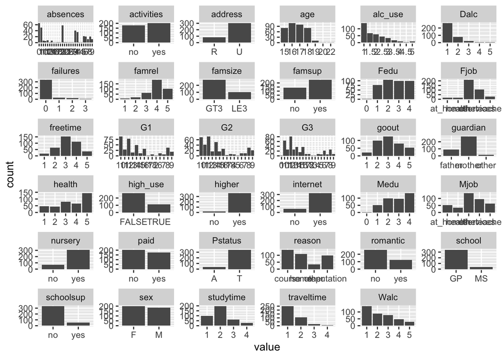

```r
gather(alc) %>% ggplot(aes(value)) + facet_wrap("key", scales = "free") + geom_bar()
```

There are 382 observations (rows) and 35 variables (columns). Variables in the data are for example school, sex, age, adress, family size, family educational support, free time after school and internet access at home. For more detailed explanation of the variables, please visit: https://archive.ics.uci.edu/ml/datasets/Student+Performance

Hypothesis 1: There is a relationship between alcohol use and student’s grade.

```r
attach(alc)
table(G3,high_use,sex)
```

```
## , , sex = F
##
##     high_use
## G3   FALSE TRUE
##   0      0    0
##   2      0    0
##   3      0    0
##   4      3    0
##   5      3    0
##   6     11    2
##   7      3    1
##   8     14    3
##   9      2    1
##   10    25    6
##   11    10    6
```

[output cut: 30 more lines]

```r
library(ggplot2)
```

Initialise a plot of high_use and G3

```r
g1 <- ggplot(alc, aes(x = high_use, y = G3, col = sex))
```

Define the plot as a boxplot and draw it.

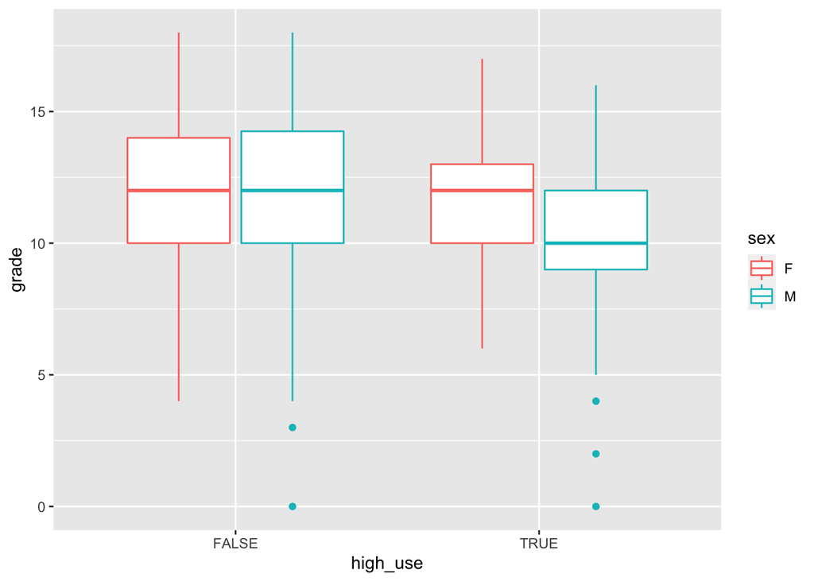

```r
g1 + geom_boxplot() + ylab("grade")
```

Initialise a plot of high use and sex.

```r
g2<-ggplot(data = alc, aes(x = high_use, fill = sex))
```

Define the plot as a bar lot and draw it.

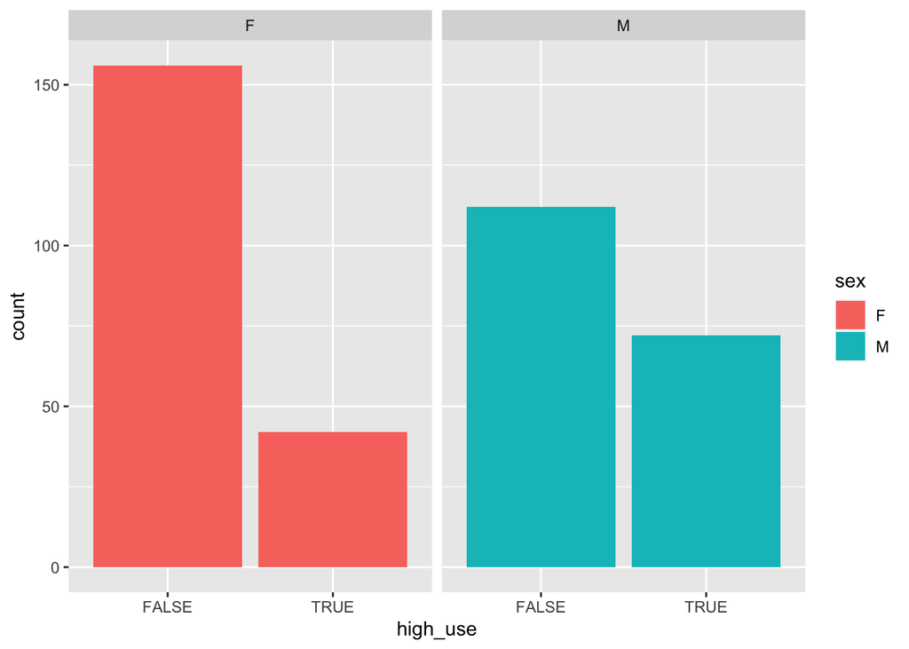

```r
g2 + geom_bar()+facet_wrap("sex")
```

Male students who have high usage of alcohol (use a lot of alcohol) have lower grades than men who do not use a lot of alcohol. For female students, the high use of alcohol does not affect the grade.

Hypothesis 2: There is a relationship between alcohol use and student’s absences.

```r
attach(alc)
table(G3,absences,sex)
```

```
## , , sex = F
##
##     absences
## G3    0  1  2  3  4  5  6  7  8  9 10 11 12 13 14 16 17 18 19 20 21 26 27 29 44
##   0   0  0  0  0  0  0  0  0  0  0  0  0  0  0  0  0  0  0  0  0  0  0  0  0  0
##   2   0  0  0  0  0  0  0  0  0  0  0  0  0  0  0  0  0  0  0  0  0  0  0  0  0
##   3   0  0  0  0  0  0  0  0  0  0  0  0  0  0  0  0  0  0  0  0  0  0  0  0  0
##   4   1  0  1  1  0  0  0  0  0  0  0  0  0  0  0  0  0  0  0  0  0  0  0  0  0
##   5   0  0  2  0  0  0  1  0  0  0  0  0  0  0  0  0  0  0  0  0  0  0  0  0  0
##   6   5  3  0  1  1  2  1  0  0  0  0  0  0  0  0  0  0  0  0  0  0  0  0  0  0
##   7   0  0  0  1  0  0  0  0  0  2  0  0  0  0  0  0  0  0  1  0  0  0  0  0  0
##   8   1  2  4  1  0  2  2  1  0  0  1  0  0  1  0  0  0  0  0  0  2  0  0  0  0
##   9   0  0  2  0  0  0  1  0  0  0  0  0  0  0  0  0  0  0  0  0  0  0  0  0  0
##   10  5  4  4  1  4  1  1  1  1  1  2  0  0  0  2  1  0  0  0  2  0  0  0  0  0
##   11  2  2  1  2  1  3  0  0  2  0  0  0  1  0  0  0  0  0  0  0  0  0  0  1  1
```

[output cut: 70 more lines]

```r
library(ggplot2)
```

Initialise a plot of high_use and absences.

```r
g3 <- ggplot(alc, aes(x = high_use, y = absences, col = sex))
```

Define the plot as a boxplot and draw it.

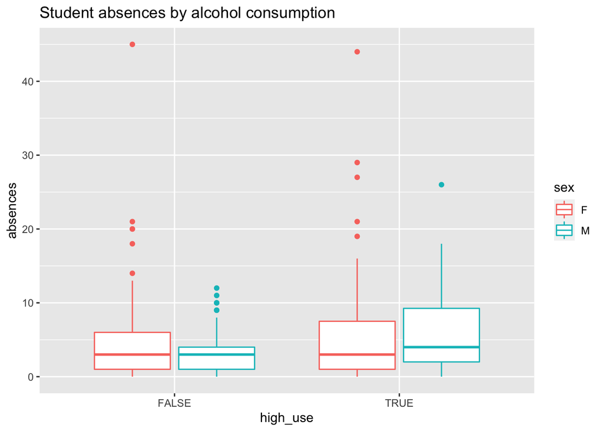

```r
g3 + geom_boxplot() + ggtitle("Student absences by alcohol consumption")
```

For male students, high users of alcohol have more absences from school. For female students, the number of absences is quite similar weather they use high amount of alcohol or not.

Hypothesis 3: There is a relationship between alcohol use and student’s health. Initialise a plot of high_use and health.

```r
g4 <- ggplot(alc, aes(x = high_use, y = health, col = sex))
```

Define the plot as a boxplot and draw it.

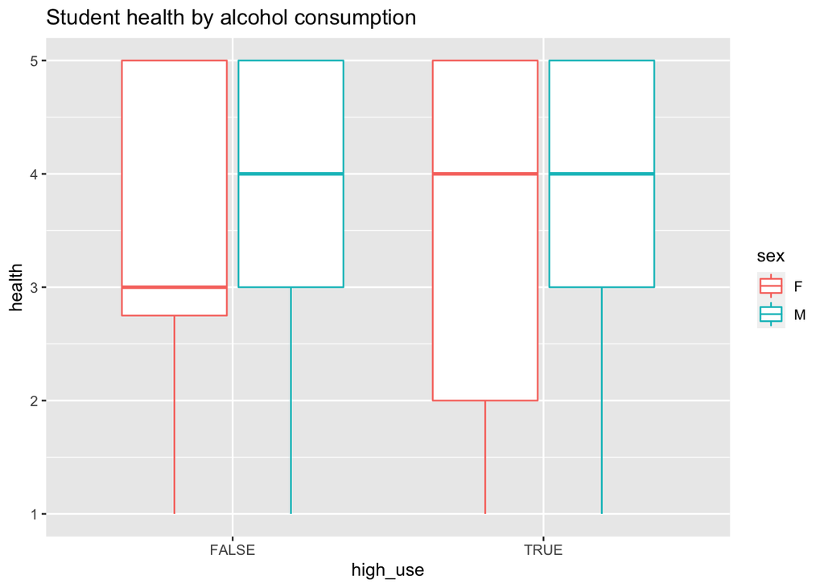

```r
g4 + geom_boxplot() + ggtitle("Student health by alcohol consumption")
```

For male students, their health score was similar weather they were high users of alcohol or not. For female students, the health score was higher for those students who were high users of alcohol, surprisingly. In high alcohol users there was a lot more variation though.

```r
g4 <- ggplot(alc, aes(x = high_use, y = goout, col = sex))
```

Define the plot as a boxplot and draw it.

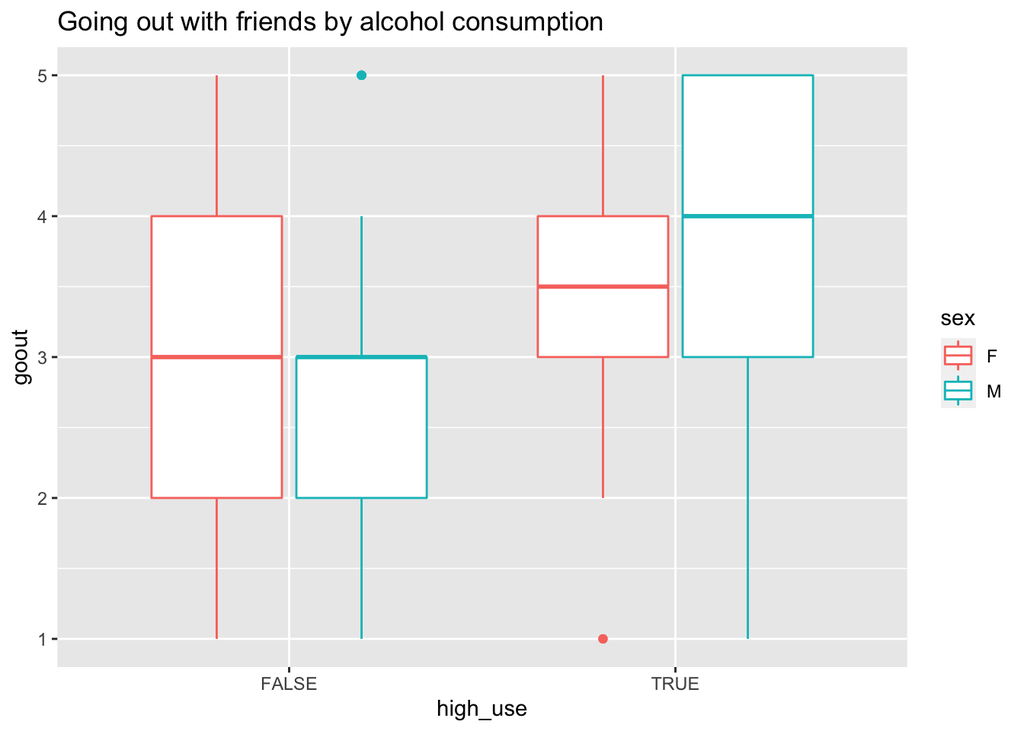

```r
g4 + geom_boxplot() + ggtitle("Going out with friends by alcohol consumption")
```

Both male and female high alcohol users go out with friends more than low alcohol users.

Find the model with glm().

```r
m <- glm(high_use ~ absences + G3 + health + goout, data = alc, family = "binomial")
```

Print out a summary of the model.

```r
summary(m)
```

```
##
## Call:
## glm(formula = high_use ~ absences + G3 + health + goout, family = "binomial",
##     data = alc)
##
## Deviance Residuals:
##     Min       1Q   Median       3Q      Max
## -1.8599  -0.7560  -0.5555   0.9414   2.3160
##
## Coefficients:
##             Estimate Std. Error z value Pr(>|z|)
## (Intercept) -3.60300    0.77329  -4.659 3.17e-06 ***
## absences     0.07508    0.02197   3.417 0.000633 ***
## G3          -0.04081    0.03843  -1.062 0.288295
## health       0.12650    0.09087   1.392 0.163897
## goout        0.72684    0.11849   6.134 8.57e-10 ***
## ---
## Signif. codes:  0 '***' 0.001 '**' 0.01 '*' 0.05 '.' 0.1 ' ' 1
##
## (Dispersion parameter for binomial family taken to be 1)
##
##     Null deviance: 465.68  on 381  degrees of freedom
## Residual deviance: 398.95  on 377  degrees of freedom
## AIC: 408.95
##
## Number of Fisher Scoring iterations: 4
```

Print out the coefficients of the model.

```r
coef(m)
```

```
## (Intercept)    absences          G3      health       goout
## -3.60300340  0.07507726 -0.04080848  0.12650463  0.72684009
```

Absences and going out with friends are highly significant predictor of the probability of being a high user of alcohol. Health and grade are not significant predictor of the probability of being a high user of alcohol.

Present and interpret the coefficients of the model as odds ratios and provide confidence intervals for them. Find the model with glm().

```r
m <- glm(high_use ~ absences + G3 + health + goout, data = alc, family = "binomial")
```

Compute odds ratios (OR).

```r
OR <- coef(m) %>% exp
```

Compute confidence intervals (CI).

```r
CI <- confint(m) %>% exp
```

Print out the odds ratios with their confidence intervals

```r
cbind(OR, CI)
```

```
##                     OR       2.5 %   97.5 %
## (Intercept) 0.02724178 0.005694834 0.118851
## absences    1.07796743 1.034131788 1.128425
## G3          0.96001298 0.890279078 1.035492
## health      1.13485470 0.951360927 1.359672
## goout       2.06853388 1.649082084 2.626747
```

Absences, health, and going out with friends are all positively associated with high use of alcohol whereas grades is negatively associated with high alcohol use. Every absence causes the student 8 % more likely to be a high user of alcohol. For every increase in the health score the student is 13.5% more likely to be a high user of alcohol. Each time the student goes out with friends, they are 107 % more likely to be a high user of alcohol. For every increase in the grade the student is 4 % less likely to be a high user of alcohol.

Fit the model.

```r
m <- glm(high_use ~ absences + goout, data = alc, family = "binomial")
```

Exploring the predictive power of the model.

Fit the model using only the variables that had a statistical relationship with high/low alcohol consumption.

```r
m <- glm(high_use ~ absences + goout, data = alc, family = "binomial")
```

Predict() the probability of high_use.

```r
probabilities <- predict(m, type = "response")
```

Add the predicted probabilities to ‘alc’.

```r
alc <- mutate(alc, probability = probabilities)
```

Use the probabilities to make a prediction of high_use.

```r
alc <- mutate(alc, prediction = probability > 0.5)
```

See the last ten original classes, predicted probabilities, and class predictions.

```r
select(alc, failures, absences, sex, high_use, probability, prediction) %>% tail(10)
```

```
##     failures absences sex high_use probability prediction
## 373        1        0   M    FALSE  0.10204808      FALSE
## 374        1        7   M     TRUE  0.28913349      FALSE
## 375        0        1   F    FALSE  0.20395640      FALSE
## 376        0        6   F    FALSE  0.27356268      FALSE
## 377        1        2   F    FALSE  0.11705469      FALSE
## 378        0        2   F    FALSE  0.36613754      FALSE
## 379        2        2   F    FALSE  0.11705469      FALSE
## 380        0        3   F    FALSE  0.06419413      FALSE
## 381        0        4   M     TRUE  0.58446429       TRUE
## 382        0        2   M     TRUE  0.05971939      FALSE
```

Tabulate the target variable versus the predictions

```r
table(high_use = alc$high_use, prediction = alc$prediction)
```

```
##         prediction
## high_use FALSE TRUE
##    FALSE   245   23
##    TRUE     67   47
```

23 times the prediction is “high alcohol use” when the variable is not “high alcohol use”. 67 times the prediction is not “high alcohol use” when the variable is “high alcohol use”.

Access dplyr and ggplot2.

```r
library(dplyr); library(ggplot2)
```

A graphic visualizing both the actual values and the predictions.

Initialize a plot of ‘high_use’ versus ‘probability’ in ‘alc’.

```r
g <- ggplot(alc, aes(x = probability, y = high_use, col = prediction))
```

Define the geom as points and draw the plot.

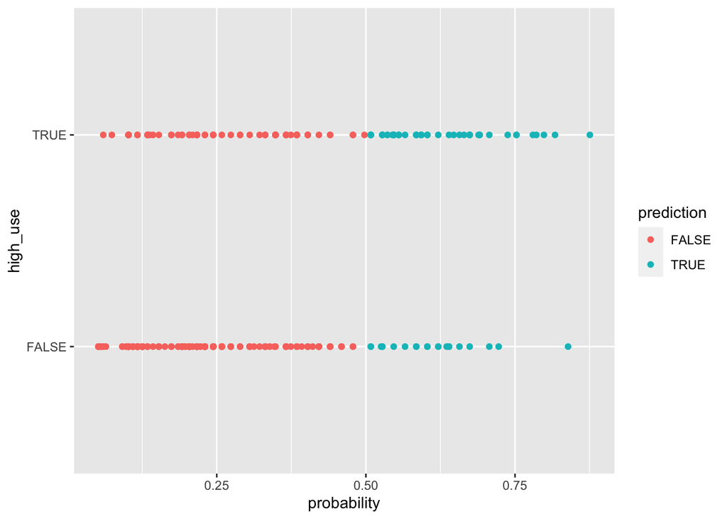

```r
g + geom_point()
```

Tabulate the target variable versus the predictions.

```r
table(high_use = alc$high_use, prediction = alc$prediction) %>% prop.table %>% addmargins
```

```
##         prediction
## high_use      FALSE       TRUE        Sum
##    FALSE 0.64136126 0.06020942 0.70157068
##    TRUE  0.17539267 0.12303665 0.29842932
##    Sum   0.81675393 0.18324607 1.00000000
```

According to the prediction, 82% of all the students are not high alcohol users. According to the actual values 70% of all the students are not high alcohol users. There is a quite big difference between the prediction and the actual model. Compute the total proportion of inaccurately classified individuals (the training error).

Define a loss function (average prediction error).

```r
loss_func <- function(class, prob) {
  n_wrong <- abs(class - prob) > 0.5
  mean(n_wrong)
}
```

Call loss_func to compute the average number of wrong predictions in the (training) data.

```r
loss_func(class = alc$high_use, prob = alc$probability)
```

```
## [1] 0.2356021
```

The training error is about 24%, which shows that the accuracy of the model is about 76%.